# P3_GroupDelta

Sameena Thabassum,Shravan Bittla, Satish Penumarti

January 18, 2017

# Q1

```r
evalclass<-function(dt)
{
  tn<-0
  tp<-0
  fp<-0
  fn<-0
  class<-dt[,2]
  pred<-dt[,3]
  for(i in 1:nrow(dt))
  {
    if(class[i]==pred[i])
    {
      if(pred[i]==1)
      {
        tp<-tp+1
      }
      else
      {
        tn<-tn+1
      }
    }
    else
    {
      if(pred[i]==1)
      {
        fp<-fp+1
      }
      else
      {
        fn<-fn+1
      }
    }
  }
  # print(paste("tp",tp))
  # print(paste("tn",tn))
  # print(paste("fp",fp))
  # print(paste("fn",fn))
  tpr<-tp/(tp+fn)
  tnr<-tn/(tn+fp)
  fpr<-fp/(tn+fp)
  sens<-tpr
  spec<-tnr
  precision<-tp/(tp+fp)
  recall<-tp/(tp+fn)
accu<-(tp+tn)/(tp+fp+fn+tn)
err<-1-accu
retr<-list(tpr,tnr,fpr,sens,spec,precision,recall,accu,err)
return(retr)
  }
```

# Q2

```r
acc<-vector('numeric')
tpr<-vector('numeric')
tnr<-vector('numeric')
fpr<-vector('numeric')
sample<-c(1:10)
ytrue<-c(1,0,1,1,0,0,1,0,1,0)
ypred<-c(0.98,0.92,0.85,0.77,0.71,0.64,0.50,0.39,0.34,0.31)
yp<-vector('numeric')
q2<-data.frame(sample,ytrue,ypred)
for(i in 1:nrow(q2))
{
    tres<-q2$ypred[i]
    for(j in 1:length(q2$ypred))
    {
      if(q2$ypred[j]>=tres)
      {
        yp[j]<-1
      }
      else
      {
        yp[j]<-0
      }
    }
    dt<-data.frame(sample,ytrue,yp)
    result<-evalclass(dt)
    acc[i]<-result[[8]]
    tpr[i]<-result[[1]]
    tnr[i]<-result[[2]]
    fpr[i]<-result[[3]]
}
q2res<-data.frame(sample,tpr,tnr,fpr,acc)
print(q2res)
```

```
##    sample tpr tnr fpr acc
## 1       1 0.2 1.0 0.0 0.6
## 2       2 0.2 0.8 0.2 0.5
## 3       3 0.4 0.8 0.2 0.6
## 4       4 0.6 0.8 0.2 0.7
## 5       5 0.6 0.6 0.4 0.6
## 6       6 0.6 0.4 0.6 0.5
## 7       7 0.8 0.4 0.6 0.6
## 8       8 0.8 0.2 0.8 0.5
## 9       9 1.0 0.2 0.8 0.6
## 10     10 1.0 0.0 1.0 0.5
```

# Q3

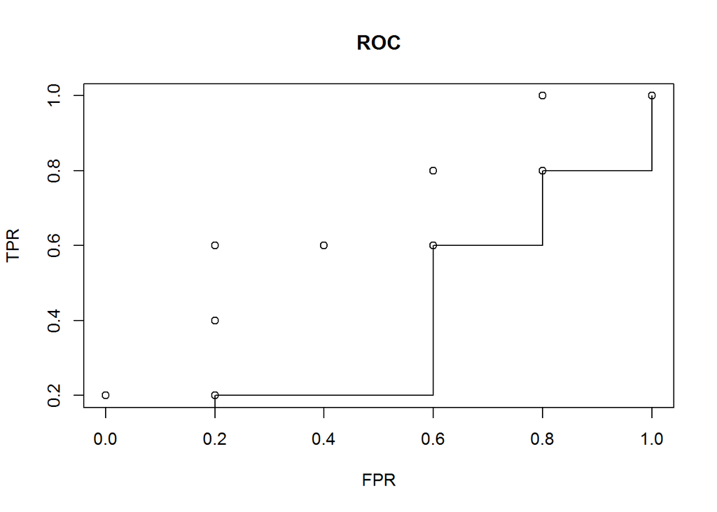

```r
plot(fpr,tpr,xlab = "FPR",ylab="TPR",main = "ROC")
lines(tpr,fpr)
```

# Q4

```r
M1<-c(30.5,32.2,20.7,20.6,31.0,41.0,27.7,26.0,21.5,26.0)
M2<-c(22.4,14.5,22.4,19.6,20.7,20.4,22.1,19.4,16.2,35.0)
avgM1<-mean(M1)
avgM2<-mean(M2)
print(paste("average error rate of model M1",avgM1))
```

```
## [1] "average error rate of model M1 27.72"
```

```r
print(paste("average error rate of model M2",avgM2))
```

```
## [1] "average error rate of model M2 21.27"
```

# Q5a

# GINI for first Node

```r
N<- c(100,50,60)
prob<-function(x){
  x/210
}
d<-prob(N)
GINI_N=1-sum(d^2)
print(GINI_N)
```

```
## [1] 0.6349206
```

# GINI for N11 Node

```r
N1<- c(62,8,0)
prob<-function(x){
  x/70
}
d1<-prob(N1)
GINI_N1=1-sum(d1^2)
print(GINI_N1)
```

```
## [1] 0.202449
```

```r
#GINI for N12 Node
N2<- c(38,42,60)
prob<-function(x){
  x/140
}
d2<-prob(N2)
GINI_N2=1-sum(d2^2)
print(GINI_N2)
```

```
## [1] 0.6526531
```

```r
#GINI for N21 Node
N3<- c(65,20,0)
prob<-function(x){
  x/85
}
d3<-prob(N3)
GINI_N3=1-sum(d3^2)
print(GINI_N3)
```

```
## [1] 0.3598616
```

```r
#GINI for N22 Node
N4<- c(21,19,20)
prob<-function(x){
  x/60
}
d4<-prob(N4)
GINI_N4=1-sum(d4^2)
print(GINI_N4)
```

```
## [1] 0.6661111
```

# GINI for N23 Node

```r
N5<- c(14,11,40)
prob<-function(x){
  x/65
}
d5<-prob(N5)
GINI_N5=1-sum(d5^2)
print(GINI_N5)
```

```
## [1] 0.5462722
```

# Gain for Split 1

```r
split1 <- GINI_N-(GINI_N1*sum(N1)+GINI_N2*sum(N2))/(sum(N1)+sum(N2))
split2 <- GINI_N-(GINI_N3*sum(N3)+GINI_N4*sum(N4)+GINI_N5*sum(N5))/(sum(N3)+sum(N4)+sum(N5))
print(split1)
```

```
## [1] 0.1323356
```

```r
print(split2)
```

```
## [1] 0.1298607
```

# Q5b

We prefer Split 1 beacause the gain in GINI for split 1 is here then compared to split2 so the next prefer node would be N11

# Q5c

```r
##PartC Gain Based on entropy
##Node N
d11=log(d)
Entropy=-(d*d11)
first=sum(Entropy)
print(paste("Entropy for N :",first))
```

```
## [1] "Entropy for N : 1.05292256593869"
```

```r
##Node N1

d1n<-c(0.886,0.114,0.01)
d12=log(d1n)
Entropy1=-(d1*d12)
second=sum(Entropy1)
print(paste("Entropy for N11 :",second ))
```

```
## [1] "Entropy for N11 : 0.355383300058266"
```

```r
##Node N12

d1k=log(d2)
Entropy2=-(d2*d1k)
third=sum(Entropy2)
print(paste("Entropy for N12 :",third ))
```

```
## [1] "Entropy for N12 : 1.07827762424623"
```

```r
##Node N21
d3n<-c(0.765,0.235,0.0001)
d13=log(d3n)
Entropy3=-(d3n*d13)
fourth=sum(Entropy3)
print(paste("Entropy for N21 :",fourth ))
```

```
## [1] "Entropy for N21 : 0.546168704318157"
```

```r
##Node N22
d14=log(d4)
Entropy4=-(d4*d14)
fifth=sum(Entropy4)
print(paste("Entropy for N22 :",fifth ))
```

```
## [1] "Entropy for N22 : 1.09777860776487"
```

```r
##Node N23
d15=log(d5)
Entropy5=-(d5*d15)
sixth=sum(Entropy5)
print(paste("Entropy for N23 :",sixth ))
```

```
## [1] "Entropy for N23 : 0.930097596357896"
```

```r
##Gain Entropy for Split 1
Gain1=first-(second*sum(N1)+third*sum(N2))/(sum(N1)+sum(N2))
print(Gain1)
```

```
## [1] 0.2156097
```

```r
##Gain Entropy for Split2
Gain2=first-(fourth*sum(N3)+fifth*sum(N4)+sixth*sum(N5))/(sum(N3)+sum(N4)+sum(N5))
print(Gain2)
```

```
## [1] 0.2303159
```

# Q5d

We prefer the split 2 because the gain value for split2 is higher when compared to split1.SO the next node would be N21

# Q6a

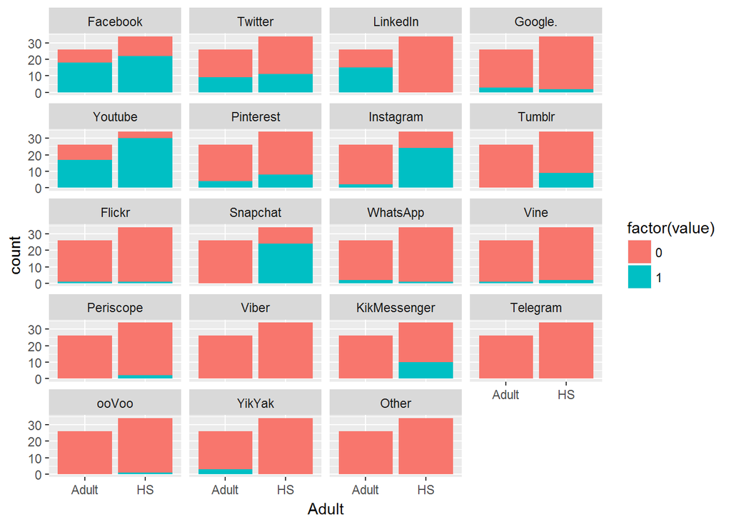

```r
q6<-read.csv("syp-16-data.csv")
#install.packages("ggplot2")
library(ggplot2)
#install.packages("reshape2")
library(reshape2)
q6melt = melt(q6)
ggplot(data = q6melt, aes(x=Adult, fill=factor(value)))+ geom_bar()+ facet_wrap(~variable, nrow = 5)
```

# Q6b

SnapChat because the difference between high school and adult users for snapchat is the highest

# Q6c

```r
library(rpart)
```

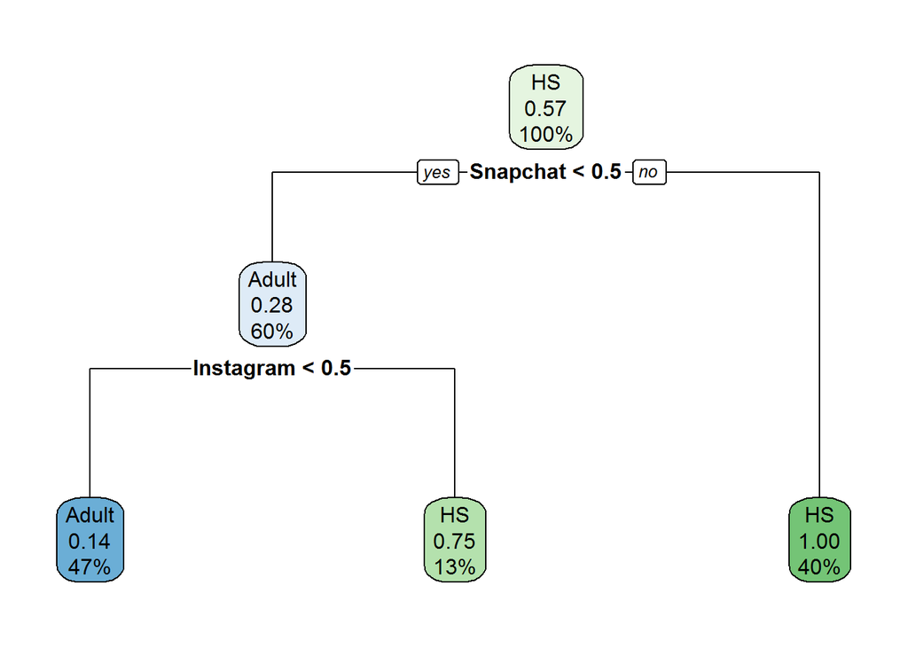

```r
library(rpart.plot)
TreeModel<- rpart(Adult~.,data=q6,method="class")
rpart.plot(TreeModel)
```

# Q7a

```r
set.seed(111)
spamd <- read.csv("spam.csv")
#spamd<-spam[,c(-1,-2,-7,-11,-19,-20)]
str(spamd)
```

```
## 'data.frame':    2171 obs. of  21 variables:
##  $ isuid      : int  1 1 1 1 1 1 1 1 1 1 ...
##  $ id         : int  1 2 3 4 5 6 7 8 9 10 ...
##  $ day.of.week: Factor w/ 7 levels "Fri","Mon","Sat",..: 5 5 5 5 5 5 5 5 5 5 ...
##  $ time.of.day: int  0 0 14 3 3 4 4 5 6 6 ...
##  $ size.kb    : int  7 2 3 3 4 4 3 2 3 1 ...
##  $ box        : Factor w/ 2 levels "no","yes": 1 1 1 2 1 1 1 2 2 1 ...
##  $ domain     : Factor w/ 44 levels "at","bak","be",..: 10 10 14 13 43 43 3 13 14 13 ...
##  $ local      : Factor w/ 2 levels "no","yes": 1 1 2 1 1 1 1 1 2 1 ...
##  $ digits     : int  0 0 0 0 0 0 1 0 0 0 ...
##  $ name       : Factor w/ 3 levels "empty","name",..: 2 2 2 2 2 2 2 2 2 3 ...
##  $ cappct     : num  0.1935 0.1915 0.0741 0.2 0.4348 ...
##  $ special    : int  1 5 2 0 2 1 1 0 1 0 ...
##  $ credit     : Factor w/ 2 levels "no","yes": 1 1 1 1 1 1 1 1 1 1 ...
##  $ sucker     : Factor w/ 2 levels "no","yes": 1 1 1 1 1 1 1 1 1 1 ...
##  $ porn       : Factor w/ 2 levels "no","yes": 1 1 1 1 1 1 1 1 1 1 ...
##  $ chain      : Factor w/ 2 levels "no","yes": 1 1 2 1 1 1 1 1 1 1 ...
##  $ username   : Factor w/ 2 levels "no","yes": 1 1 1 1 1 1 1 1 1 1 ...
##  $ large.text : Factor w/ 2 levels "no","yes": 1 1 1 1 1 1 1 1 1 1 ...
##  $ spampct    : int  NA NA 13 NA NA NA NA NA NA NA ...
##  $ category   : Factor w/ 4 levels "com","list","news",..: 3 1 2 4 2 2 2 4 4 4 ...
##  $ spam       : Factor w/ 2 levels "no","yes": 1 2 1 1 1 1 1 1 1 1 ...
```

# Q7b

```r
library(caTools)
##Sampling the data
ind<- sample.split(Y = spamd$spam,SplitRatio=0.8)
traind<-spamd[ind,]
testd<-spamd[!ind,]
```

# Q7c

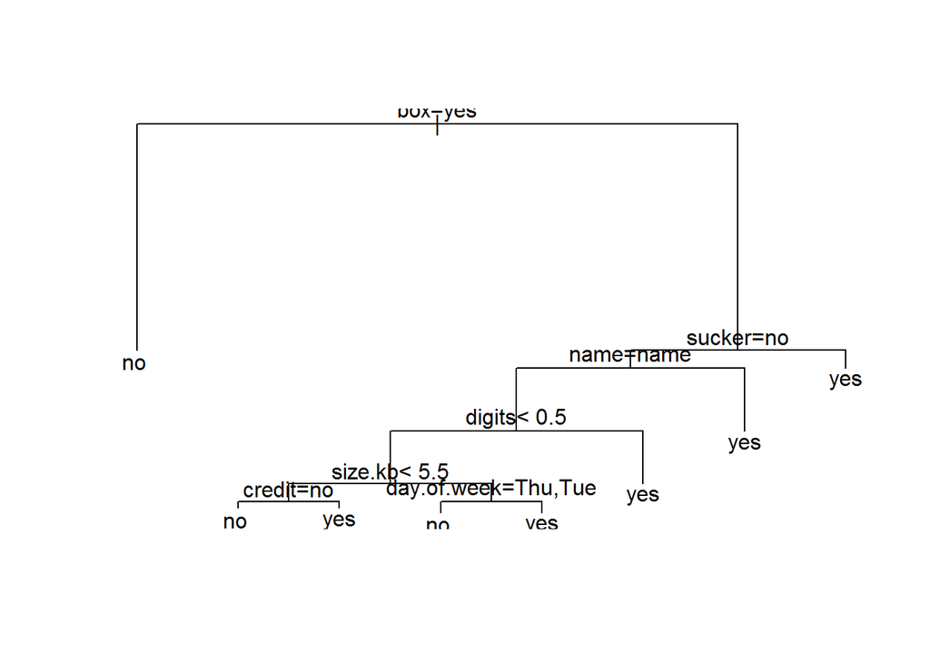

```r
##Fitting the Model
DecisionTreeModel<- rpart(spam ~. ,data=spamd,method='class')

DecisionTreeModel<- rpart(spam ~ day.of.week+size.kb+box+digits+name+credit+special+porn+sucker, data=traind,method="class")
plot(DecisionTreeModel)
text(DecisionTreeModel, pretty=0)
```

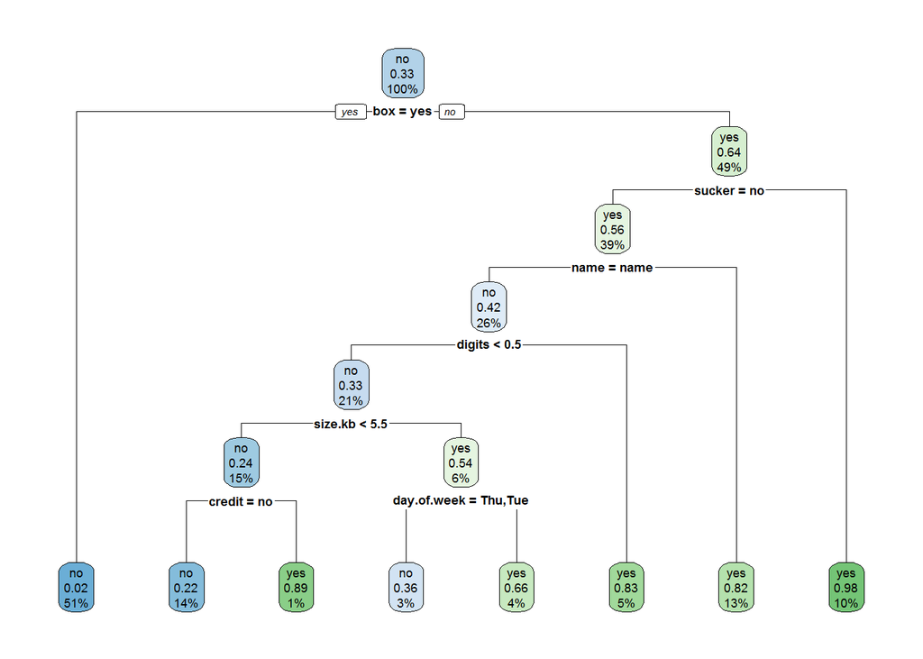

```r
rpart.plot(DecisionTreeModel)
```

```r
summary(DecisionTreeModel)
```

```
## Call:
## rpart(formula = spam ~ day.of.week + size.kb + box + digits +
##     name + credit + special + porn + sucker, data = traind, method = "class")
##   n= 1737
##
##           CP nsplit rel error    xerror       xstd
## 1 0.42605634      0 1.0000000 1.0000000 0.03442177
## 2 0.05985915      1 0.5739437 0.5739437 0.02864996
## 3 0.01848592      4 0.3556338 0.3556338 0.02352240
## 4 0.01232394      6 0.3186620 0.3644366 0.02377293
## 5 0.01000000      7 0.3063380 0.3345070 0.02290202
##
## Variable importance
##         box      sucker        name      digits     size.kb     special
##          42          14          13          12          11           5
##      credit day.of.week
##           1           1
##
## Node number 1: 1737 observations,    complexity param=0.4260563
##   predicted class=no   expected loss=0.3270006  P(node) =1
##     class counts:  1169   568
##    probabilities: 0.673 0.327
##   left son=2 (887 obs) right son=3 (850 obs)
##   Primary splits:
##       box     splits as  RL,       improve=331.06810, (0 missing)
##       sucker  splits as  LR,       improve=157.53190, (0 missing)
##       digits  < 0.5  to the left,  improve=120.34690, (0 missing)
##       name    splits as  LLR,      improve= 85.46749, (0 missing)
##       size.kb < 3.5  to the left,  improve= 64.10424, (0 missing)
##   Surrogate splits:
##       size.kb < 2.5  to the left,  agree=0.617, adj=0.216, (0 split)
##       digits  < 0.5  to the left,  agree=0.604, adj=0.192, (0 split)
##       sucker  splits as  LR,       agree=0.602, adj=0.186, (0 split)
##       name    splits as  RLR,      agree=0.596, adj=0.174, (0 split)
##       special < 1.5  to the left,  agree=0.571, adj=0.124, (0 split)
##
## Node number 2: 887 observations
##   predicted class=no   expected loss=0.02480271  P(node) =0.5106505
##     class counts:   865    22
##    probabilities: 0.975 0.025
```

[output cut: 98 more lines]

```
##
## Node number 97: 9 observations
##   predicted class=yes  expected loss=0.1111111  P(node) =0.005181347
##     class counts:     1     8
##    probabilities: 0.111 0.889
##
## Node number 98: 44 observations
##   predicted class=no   expected loss=0.3636364  P(node) =0.02533103
##     class counts:    28    16
##    probabilities: 0.636 0.364
##
## Node number 99: 67 observations
##   predicted class=yes  expected loss=0.3432836  P(node) =0.03857225
##     class counts:    23    44
##    probabilities: 0.343 0.657
```

# Q7d

```r
##Predict Train
Predictd<- predict(DecisionTreeModel, traind, type='class')
t<-table(predictions=Predictd,actual=traind$spam)

print(t)
```

```
##            actual
## predictions   no  yes
##         no  1086   91
##         yes   83  477
```

```r
##Predict Test
Predictd1<- predict(DecisionTreeModel, testd, type='class')
t1<-table(predictions=Predictd1,actual=testd$spam)
print(t1)
```

```
##            actual
## predictions  no yes
##         no  268  31
##         yes  24 111
```

8 terminal nodes and 15 nodes

# Q7e

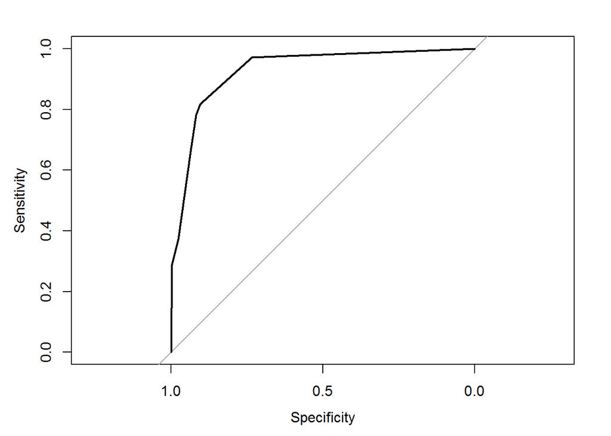

```r
##Plotting ROC Curve
library(pROC)
library(pROC)
PredictionsWithProbs<-predict(DecisionTreeModel, testd, type='prob')
auc <-auc(testd$spam,PredictionsWithProbs[,2])
plot(roc(testd$spam,PredictionsWithProbs[,2]))
```

```r
##Accuracy on Train data
accuracytrain=sum(diag(t))/sum(t)
errorrate<-1-accuracytrain
print(paste("accuracy: ",accuracytrain))
```

```
## [1] "accuracy:  0.899827288428325"
```

```r
print(paste("errorrate: ",errorrate))
```

```
## [1] "errorrate:  0.100172711571675"
```

```r
##Accuracy on Testdata
accuracytest=sum(diag(t1))/sum(t1)
errorrate1<-1-accuracytest
print(paste("accuracy: ",accuracytest))
```

```
## [1] "accuracy:  0.873271889400922"
```

```r
print(paste("errorrate: ",errorrate1))
```

```
## [1] "errorrate:  0.126728110599078"
```

# Q7f

```r
#pruning
printcp(DecisionTreeModel)
```

```
##
## Classification tree:
## rpart(formula = spam ~ day.of.week + size.kb + box + digits +
##     name + credit + special + porn + sucker, data = traind, method = "class")
##
## Variables actually used in tree construction:
## [1] box         credit      day.of.week digits      name        size.kb
## [7] sucker
##
## Root node error: 568/1737 = 0.327
##
## n= 1737
##
##         CP nsplit rel error  xerror     xstd
## 1 0.426056      0   1.00000 1.00000 0.034422
## 2 0.059859      1   0.57394 0.57394 0.028650
## 3 0.018486      4   0.35563 0.35563 0.023522
## 4 0.012324      6   0.31866 0.36444 0.023773
## 5 0.010000      7   0.30634 0.33451 0.022902
```

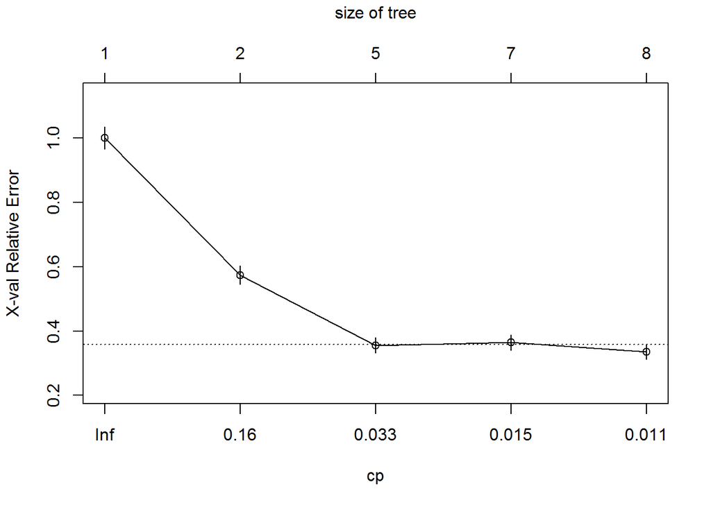

```r
plotcp(DecisionTreeModel)
```

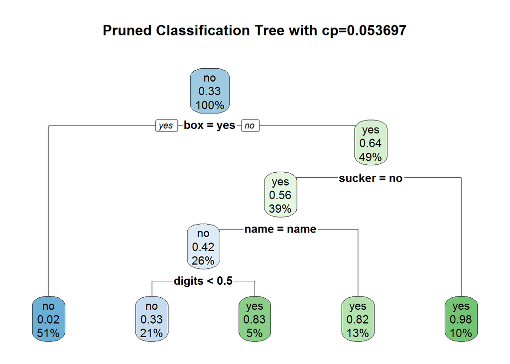

```r
#ptree<-prune(DecisionTreeModel,cp=DecisionTreeModel$cptable[which.min(DecisionTreeModel$cptable[,"xerror"]),"CP"])
ptree1<-prune(DecisionTreeModel,cp=0.053697)
rpart.plot(ptree1,uniform=TRUE,main="Pruned Classification Tree with cp=0.053697")
```

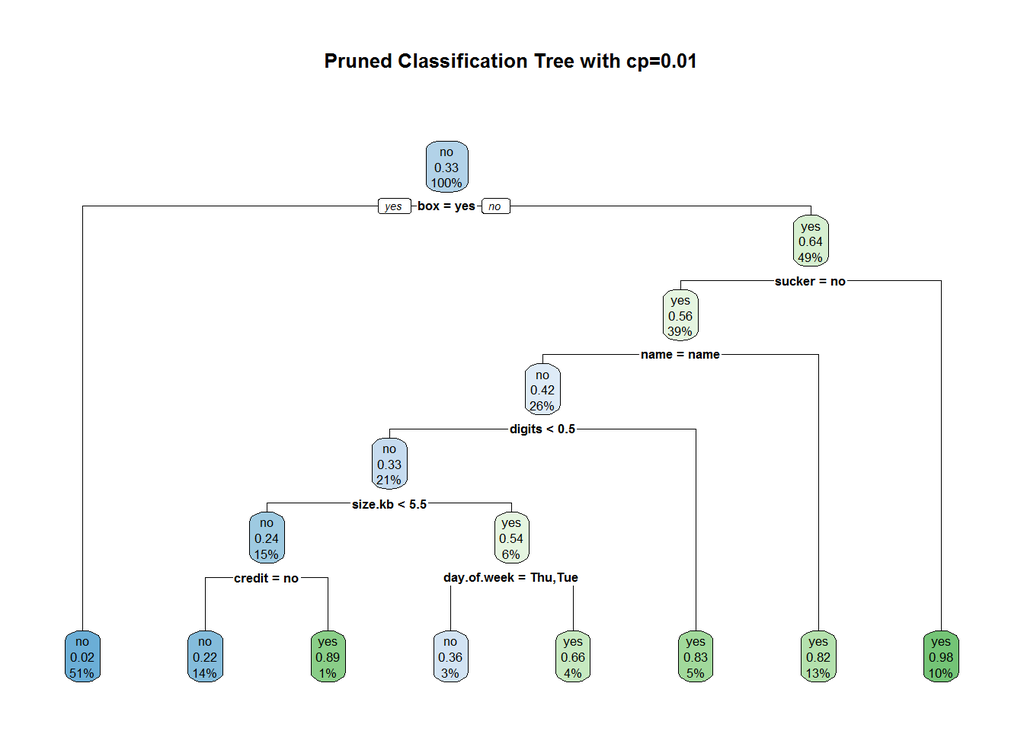

```r
ptree2<-prune(DecisionTreeModel,cp=0.01)
rpart.plot(ptree2,uniform=TRUE,main="Pruned Classification Tree with cp=0.01")
```

The value of cp should be least so that xerror is minimum

# Q8

# 8a

```r
q3<-read.csv("music.csv",header = T)
q3sub<-q3[,c(-2,-3,-4,-5)]
```

# 8b

```r
q3c0<-q3sub[which(q3$Top10==0),]
q3c1<-q3sub[which(q3$Top10==1),]
nrow(q3c0)
```

```
## [1] 6455
```

```r
nrow(q3c1)
```

```
## [1] 1119
```

we can have 6455 top10 value =0 and 1119 top10 value= 1 9 folds with 757 rows(112 top10=1 ,645 top10=0) each and 10th fold will have 761 rows(111 top10=1 ,650 top10=0)

```r
l<-1
r<-645
folds<-list()
for(i in 1:9)
{
  folds[[i]]<-q3c0[l:r,]
  l<-l+645
  r<-r+645
}
folds[[10]]<-q3c0[l:nrow(q3c0),]
l<-1
r<-112
for(i in 1:9)
{
  folds[[i]]<-rbind(folds[[i]],q3c1[l:r,])
  l<-l+112
  r<-r+112
}
folds[[10]]<-rbind(folds[[10]],q3c1[l:nrow(q3c1),])
```

# 8c

```r
# lib
knnfun<-function(knn)
{
  library(pROC)
  library(class)
  library(ROCR)
predobj<-lapply( rep("prediction", 10), new )
prefobj<-lapply( rep("performance", 10), new )
testfold<-vector(length = 10)
aucvec<-vector(length = 10)
acc<-vector(length = 10)
err<-vector(length = 10)
for(i in 1:10)
{
  train<-as.data.frame(NULL)
  for(j in 1:10)
  {
    if(j!=i)
    {    train<-rbind(train,folds[[j]])}

  }
  test<-folds[[i]]
  pred<-knn(train,test,k=knn,cl=factor(train$Top10))
  preddt<-as.vector(pred)

    # for(l in 1:nrow(preddt))
    # {
    #   if(preddt[l,1]>preddt[l,2])
    #     preddt[l,3]=0
    #   else
    #     preddt[l,3]=1
    # }
  #pred<-as.logical(pred)
  # test$Top10<-as.logical(test$Top10)
  # preddt<-as.logical(preddt)
  test1<-cbind(test$Top10,preddt)
  test2<-as.data.frame(test1)
  test2$V1<-as.integer(test2$V1)
  test2$preddt<-as.integer(test2$preddt)
  #print(test1)
  # predobj[i]<-prediction(test$pred,test$Top10)
  # prefobj[i] <- performance(predobj[[i]],"tpr","fpr")
   aucvec[i]<-auc(test2$V1,test2$preddt)
  count<-0
for(k in 1:nrow(test1))
{
  if(test1[k,1]==test1[k,2])
    count<-count+1
}
acc[i]<-count/nrow(test1)
err[i]<-1-acc[i]
testfold[i]<-i
}
retval<-data.frame(testfold,acc,err,aucvec)
return(retval)
}
```

```r
kone<-knnfun(knn=1)
kthree<-knnfun(knn=3)
kfive<-knnfun(knn=5)
kseven<-knnfun(knn=7)
knine<-knnfun(knn=9)
print(kone)
```

```
##    testfold       acc       err    aucvec
## 1         1 0.7754293 0.2245707 0.6026024
## 2         2 0.7661823 0.2338177 0.5233942
## 3         3 0.8044914 0.1955086 0.5901440
## 4         4 0.7780713 0.2219287 0.5561946
## 5         5 0.7846764 0.2153236 0.5932724
## 6         6 0.7727873 0.2272127 0.5604720
## 7         7 0.7608983 0.2391017 0.5793189
## 8         8 0.8084544 0.1915456 0.5777132
## 9         9 0.7727873 0.2272127 0.5678502
## 10       10 0.7647832 0.2352168 0.5373389
```

```r
print(kthree)
```

```
##    testfold       acc       err    aucvec
## 1         1 0.8216645 0.1783355 0.5780869
## 2         2 0.8335535 0.1664465 0.5739964
## 3         3 0.8309115 0.1690885 0.5724460
## 4         4 0.8229855 0.1770145 0.5567276
## 5         5 0.8282695 0.1717305 0.5745847
## 6         6 0.8177015 0.1822985 0.5683832
## 7         7 0.8058124 0.1941876 0.5540282
## 8         8 0.8243065 0.1756935 0.5390573
## 9         9 0.8216645 0.1783355 0.5817760
## 10       10 0.8147175 0.1852825 0.5516286
```

```r
print(kfive)
```

```
##    testfold       acc       err    aucvec
## 1         1 0.8375165 0.1624835 0.5541874
## 2         2 0.8441215 0.1558785 0.5543743
## 3         3 0.8480845 0.1519155 0.5603890
## 4         4 0.8454425 0.1545575 0.5440822
## 5         5 0.8414795 0.1585205 0.5454457
## 6         6 0.8256275 0.1743725 0.5472107
## 7         7 0.8295905 0.1704095 0.5310908
## 8         8 0.8361955 0.1638045 0.5349668
## 9         9 0.8216645 0.1783355 0.5338178
## 10       10 0.8409987 0.1590013 0.5446015
```

```r
print(kseven)
```

```
##    testfold       acc       err    aucvec
## 1         1 0.8480845 0.1519155 0.5640781
## 2         2 0.8494055 0.1505945 0.5390296
## 3         3 0.8507266 0.1492734 0.5471830
## 4         4 0.8533686 0.1466314 0.5450443
## 5         5 0.8467635 0.1532365 0.5301011
## 6         6 0.8388375 0.1611625 0.5291390
## 7         7 0.8401585 0.1598415 0.5372924
## 8         8 0.8467635 0.1532365 0.5522356
## 9         9 0.8388375 0.1611625 0.5402063
## 10       10 0.8436268 0.1563732 0.5274636
```

```r
print(knine)
```

```
##    testfold       acc       err    aucvec
## 1         1 0.8454425 0.1545575 0.5367040
## 2         2 0.8480845 0.1519155 0.5271872
## 3         3 0.8546896 0.1453104 0.5384413
## 4         4 0.8560106 0.1439894 0.5355274
## 5         5 0.8520476 0.1479524 0.5368909
## 6         6 0.8428005 0.1571995 0.5240864
## 7         7 0.8454425 0.1545575 0.5256368
## 8         8 0.8546896 0.1453104 0.5531977
## 9         9 0.8428005 0.1571995 0.5240864
## 10       10 0.8449409 0.1550591 0.5282328
```

# Q8d

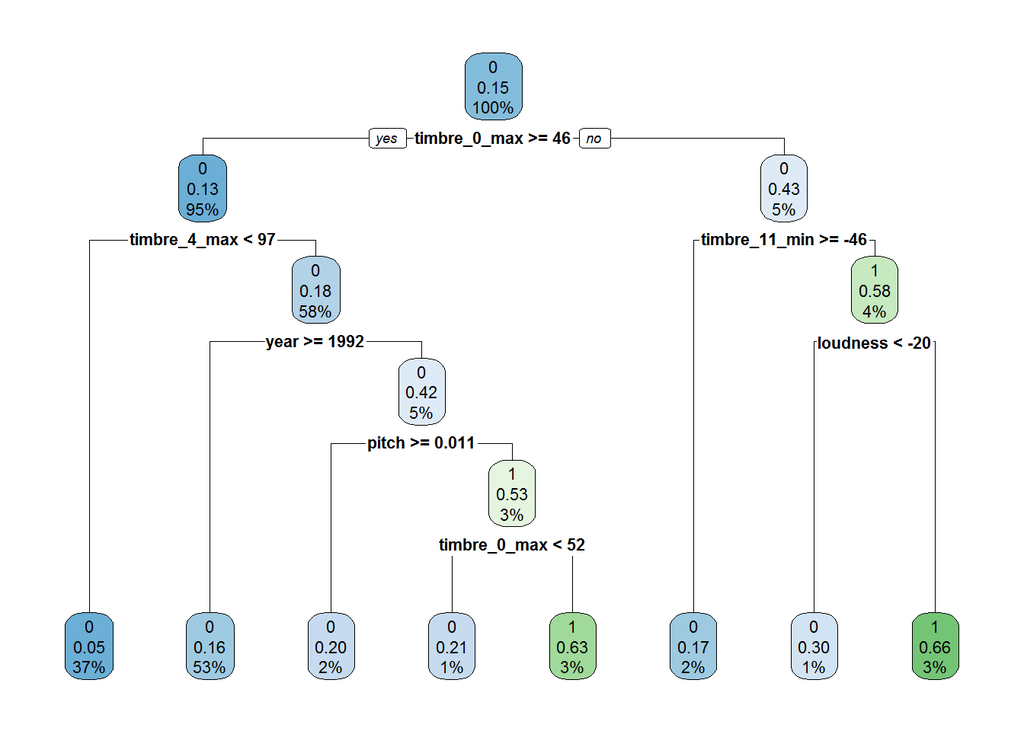

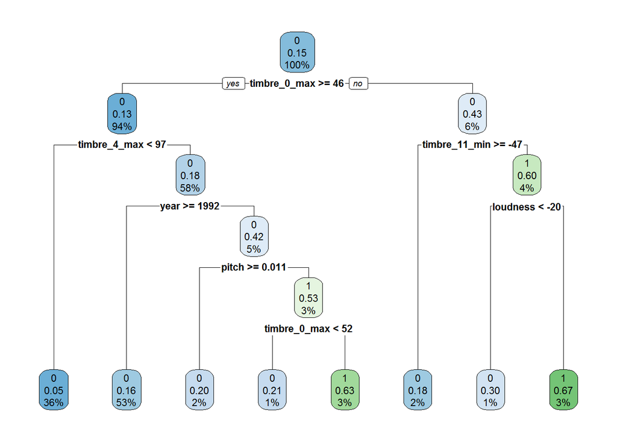

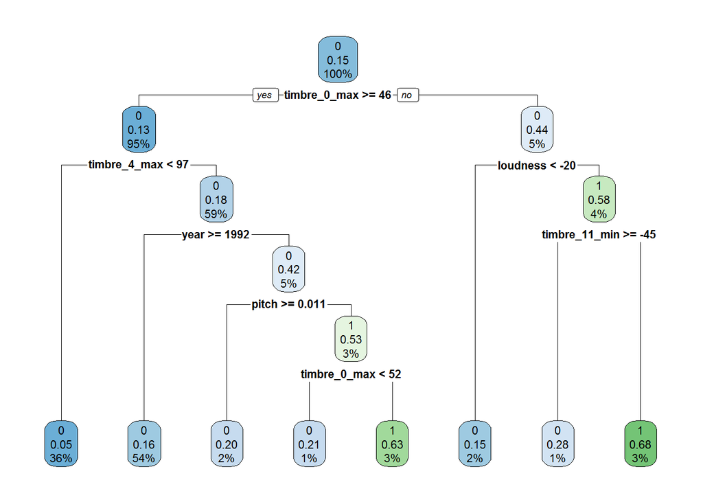

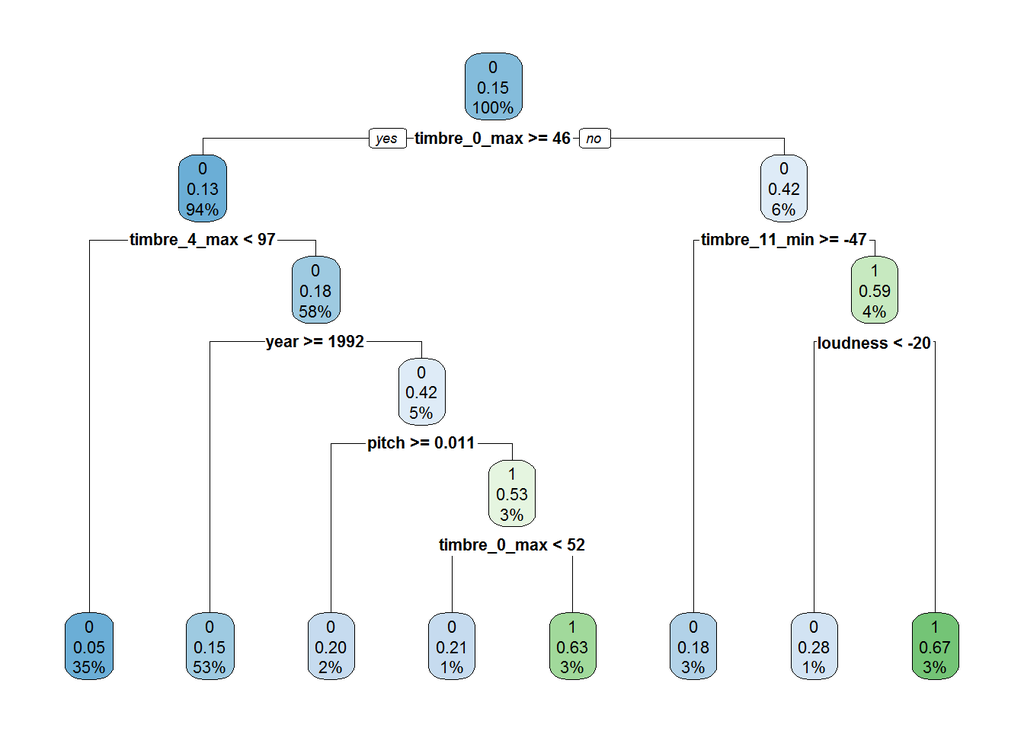

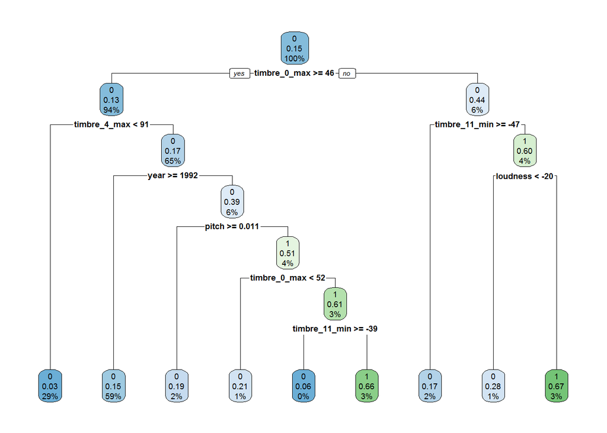

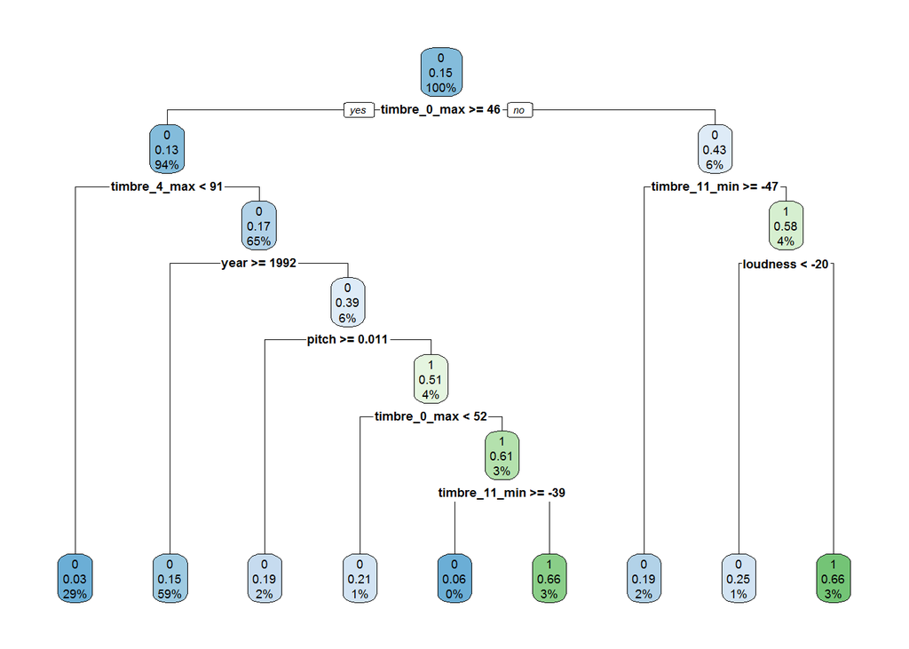

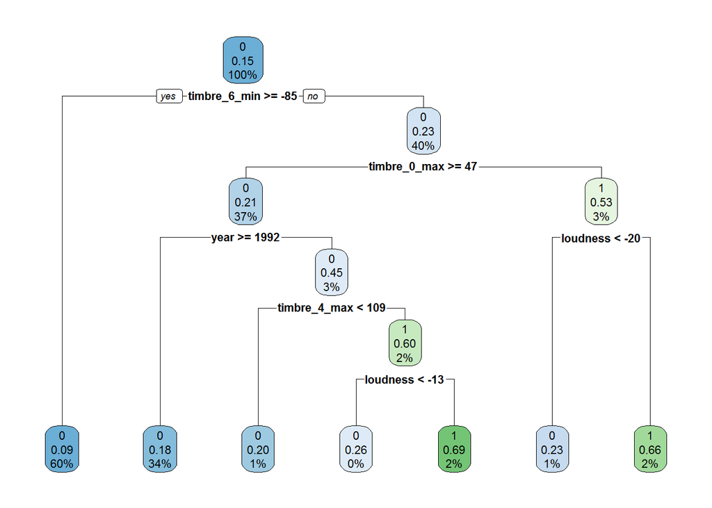

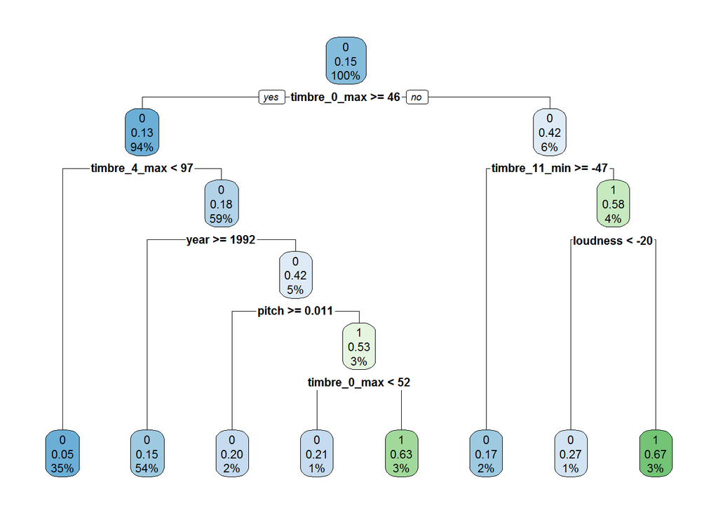

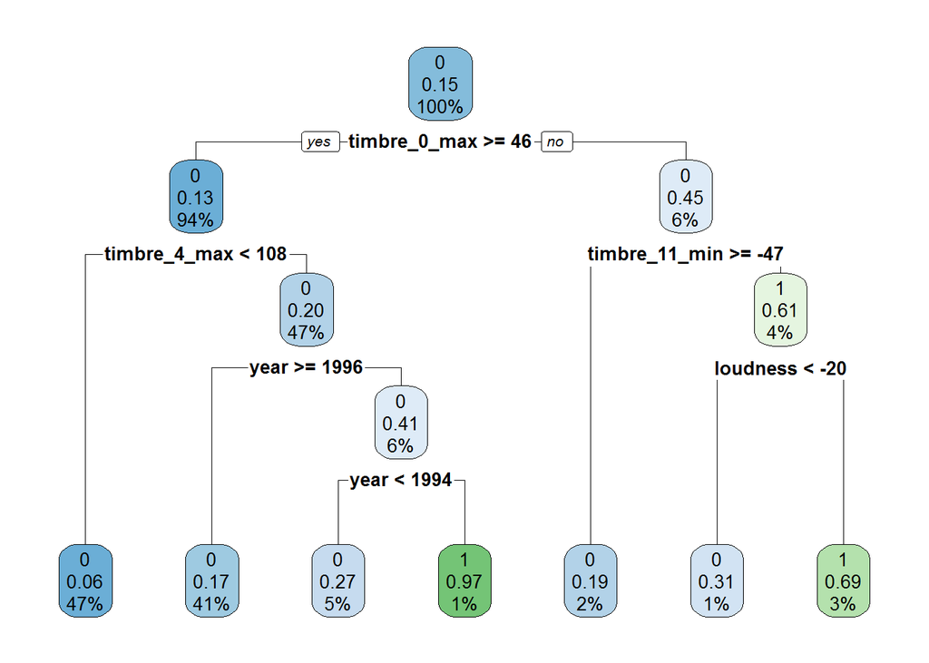

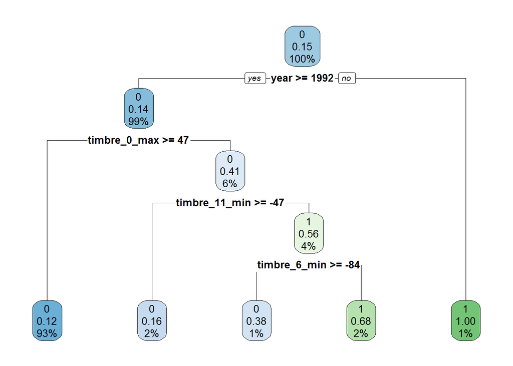

```r
# decisiontree<-function()
# {
  library(pROC)
  library(class)
library(rpart)
library(rpart.plot)
  library(ROCR)
  predobj<-lapply( rep("prediction", 10), new )
  prefobj<-lapply( rep("performance", 10), new )
  testfold<-vector(length = 10)
  aucvec<-vector(length = 10)
  acc<-vector(length = 10)
  err<-vector(length = 10)
  for(i in 1:10)
  {
    train<-as.data.frame(NULL)
    for(j in 1:10)
    {
      if(j!=i)
      {    train<-rbind(train,folds[[j]])}

    }
    test<-folds[[i]]
    fit<-rpart(Top10 ~ .,method = "class",data = train)

    rpart.plot(fit)
    pred<-predict(fit,test,method="class")
    preddt<-as.data.frame(pred)
    for(l in 1:nrow(preddt))
    {
      if(preddt[l,1]>preddt[l,2])
        preddt[l,3]=0
      else
        preddt[l,3]=1
    }
    #pred<-knn(train,test,k=knn,cl=train$Top10)
    #pred<-as.integer(pred)
    test<-cbind(test,preddt$V3)
    #predobj[i]<-prediction(test$pred,test$Top10)
    #prefobj[i] <- performance(predobj[[i]],"tpr","fpr")
    aucvec[i]<-auc(test$`preddt$V3`,test$Top10)
    count<-0
    for(k in 1:nrow(test))
    {
      if(test$Top10[k]==test$`preddt$V3`[k])
        count<-count+1
    }
    acc[i]<-count/nrow(test)
    err[i]<-1-acc[i]
    testfold[i]<-i
  }
```

```r
  retval<-data.frame(testfold,acc,err,aucvec)
  print(retval)
```

```
##    testfold       acc       err    aucvec
## 1         1 0.8665786 0.1334214 0.8943342
## 2         2 0.8560106 0.1439894 0.7210455
## 3         3 0.8586526 0.1413474 0.7480388
## 4         4 0.8560106 0.1439894 0.7305930
## 5         5 0.8520476 0.1479524 0.6803112
## 6         6 0.8612946 0.1387054 0.7544262
## 7         7 0.8731836 0.1268164 0.8416027
## 8         8 0.8586526 0.1413474 0.7337432
## 9         9 0.5627477 0.4372523 0.4346480
## 10       10 0.3337714 0.6662286 0.5898058
```

When we use seventh fold as the test data, we get the highest accuracy

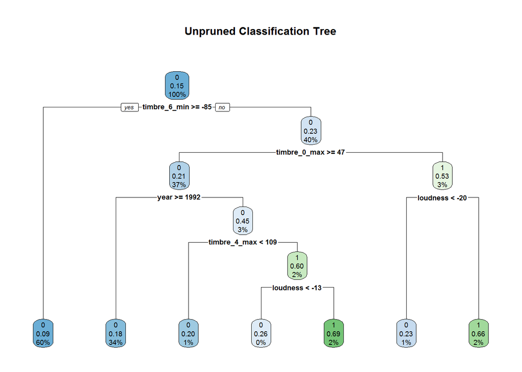

```r
#   return(retval)
# }
trainbest<-as.data.frame(NULL)
    for(j in 1:10)
    {
      if(j!=7)
      {    trainbest<-rbind(trainbest,folds[[j]])}

    }
testbest<-folds[[7]]
fit<-rpart(Top10 ~ .,method = "class",data = trainbest)
rpart.plot(fit,main="Unpruned Classification Tree")
```

```r
printcp(fit)
```

```
##
## Classification tree:
## rpart(formula = Top10 ~ ., data = trainbest, method = "class")
##
## Variables actually used in tree construction:
## [1] loudness     timbre_0_max timbre_4_max timbre_6_min year
##
## Root node error: 1007/6817 = 0.14772
##
## n= 6817
##
##         CP nsplit rel error  xerror     xstd
## 1 0.014896      0   1.00000 1.00000 0.029092
## 2 0.014399      3   0.95531 0.99106 0.028984
## 3 0.012910      5   0.92651 0.99106 0.028984
## 4 0.010000      6   0.91360 0.96723 0.028693
```

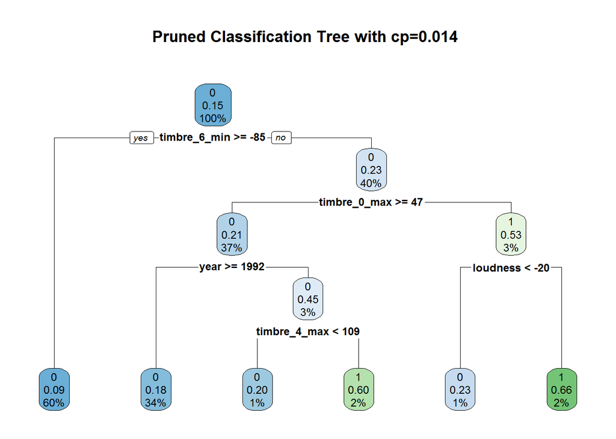

```r
#ptree<- prune(fit,cp= fit$cptable[which.min(fit$cptable[,"xerror"]),"CP"])
ptree2<-prune(fit,cp=0.014)
rpart.plot(ptree2, uniform=TRUE,main="Pruned Classification Tree with cp=0.014 ")
```

[figure not shown]

```r
ptree3<-prune(fit,cp=0.010000)
rpart.plot(ptree1, uniform=TRUE,main="Pruned Classification Tree with cp=0.010000")
```

```r
#a<-decisiontree()
#n<-a[with(a, order(a$acc)), ]

#sort(a$acc)
```

# Q8e

```r
  library(pROC)
# set.seed(123)
# s<-sample(7574,6059)
# traine<-q3sub[s,]
# teste<-q3sub[-s,]
traine<-rbind(folds[[1]],folds[[10]],folds[[3]],folds[[4]],folds[[5]],folds[[6]],folds[[7]],folds[[8]],folds[[9]])
traine$Top10<-as.logical(traine$Top10)
teste<-folds[[2]]
teste$Top10<-as.logical(teste$Top10)
library("naivebayes")
model<-naive_bayes(Top10 ~ .,data=traine)
prede<-predict(model,teste)
prede<-as.logical(prede)
testclss<-cbind(teste$Top10,prede)

    count<-0
    for(k in 1:nrow(testclss))
    {
      if(testclss[k,1]==testclss[k,2])
        count<-count+1
    }
    print(count)
```

```
## [1] 553
```

```r
    acc<-count/nrow(testclss)
    err<-1-acc
    testclss[,1]<-as.numeric(testclss[,1])
    testclss[,2]<-as.numeric(testclss[,2])
   auc<-auc(testclss[,1],testclss[,2])
    print(paste0("accuracy: ",acc))
```

```
## [1] "accuracy: 0.730515191545575"
```

```r
    print(paste0("Error rate: ",err))
```

```
## [1] "Error rate: 0.269484808454425"
```

```r
    print(paste0("AUC: ",auc))
```

```
## [1] "AUC: 0.66109496124031"
```

# Q8h

Number of negative samples should be considered as they have an effect on classification. These samples influence the performance of the classifiers. More the number of negative samples, more is the precision, given that the number of positive samples is constant. The effect of more number of negative samples increases the performance for most classifiers.